钢 + 混凝土 / 一根梁的施工历史

# 在已有变形上，继续变形

先是钢梁独自承重；混凝土硬化以后，才与钢梁共同承担新荷载。

Steel **+** Concrete

[回看抗弯课堂 ↗](https://syzhaoln-stack.github.io/bending-3d/beam-extension-3d.html)

拖动旋转 · 滚轮缩放 · 金线为一期变形基准

透视混凝土拆开构造变形放大 250×二期额外放大 3×

钢梁自重加载 100%

抽离看受力

**钢梁自重**

**混凝土自重**

**二期铺装**

**车辆等效荷载**

### 跨中累计挠度 / mm

一期保留下来

+

二期继续增加

=

当前累计

这里始终显示真实值；二期位移可额外放大。

### 混凝土压应力 · 跨中

**全截面：统一应变与应力刻度**

展开：一期 + 二期 = 累计，以及对应数据 ↓

跨中截面 / 平截面假定 / 施工历史

## 同一高度，看清两期应变怎样相加

截面、应变和应力沿同一 z 高度对齐。钢底 z = 0；钢—混凝土界面 z = 600 mm。

**平截面假定：纵向应变沿截面高度线性变化。**

一期只要求钢梁截面保持平面；二期有可靠抗剪连接后，钢梁和硬化混凝土的**新增应变**贯穿整个组合截面为一条直线。硬化前已经发生的钢梁应变还要另加回来。

全截面统一刻度 · 混凝土另附放大图 · 拉正压负

Ⅰ

### 钢梁独立的应变面

εⅠ 与 σⅠ · 钢梁自己的中性轴

ε钢,Ⅰ = κⅠ (zₛ − z)  
σ钢,Ⅰ = Eₛ ε钢,Ⅰ

湿混凝土只提供重量。本期不定义其纵向弹性受力应变，表中以“—”表示。

Ⅱ

### 组合截面的共同应变面

ΔεⅡ 与 ΔσⅡ · 整个截面的中性轴

Δε钢,Ⅱ = Δε混,Ⅱ = κⅡ (zₙ − z)  
同一应变，分别乘 Eₛ 或 E꜀ 得到应力

界面两侧的新增应变相等。弹性模量不同，所以应力图在界面发生跳变。

Σ

### 保留施工历史，再累加

材料各自的累计弹性应变与应力

钢：ε = εⅠ + ΔεⅡ；σ = σⅠ + ΔσⅡ  
混凝土：ε = ΔεⅡ；σ = ΔσⅡ

混凝土以硬化时的形状为无应力起点；累计图的界面差值来自参考起点不同，不代表正在滑移。

选同一条纤维，看两期怎样相加

三张全截面图纵向比例相同，应变与应力分别共用横向刻度；截面横向压缩示意。每张图下方的混凝土详图沿板厚局部展开，使用独立且跨阶段固定的 MPa 刻度；请按刻度读数，不跨图比较色块宽度。

## 拆成两幅图，就看清了

一期的钢梁体系 + 二期的组合体系 = 同一根梁的累计响应。

### Ⅰ 钢梁独立承担

钢梁自重 + 湿混凝土自重

挠度 δⅠ mm钢下缘 σⅠ MPa

混凝土尚未硬化，只把重量交给钢梁；这段钢梁应力不会在硬化时消失。

### Ⅱ 钢＋混凝土共同承担

后加铺装 + 车辆等效荷载

增量 δⅡ mm钢下缘 ΔσⅡ MPa

两幅图是在分解受力历史；实际使用时，钢梁与混凝土通过栓钉连成整体。

## 没有栓钉，还能“一起弯”吗？

贴在一起不等于形成组合截面。栓钉传递界面纵向剪力，限制相对滑移。

### 有可靠的抗剪连接

两种材料以共同的组合中性轴产生二期应变增量；上部板的压力与钢梁轴向拉力形成有力的抗弯力偶。

### 无纵向抗剪连接：理想自由滑移

竖向接触仍可传荷载，但两层有相对滑移，分别绕各自中性轴弯曲；不能直接使用完整组合截面的刚度。

**传力发生在哪里？** 栓钉位于钢梁上翼缘与混凝土的交界处，通过纵向剪力，使混凝土板的压力与钢梁的轴向合拉力沿梁长建立起来。本页简支均布荷载下，**跨中弯矩和板内合压力最大；界面剪流在支点附近最大、跨中为零**。整体受力依靠沿梁长的连接，竖向荷载最终传到两端支座。

这是无开裂、保持竖向接触的两个理想边界，不是实际无栓钉构件的承载力预测。真实情况还涉及开裂、接触和连接刚度。

## 同样是钢＋混凝土，钢可以换一种形状

先辨认钢截面，再看混凝土放在哪里。下列为自行绘制的构造示意，不是施工图，也不按比例。

### 钢板梁：钢板焊成工字形

钢板梁强调制造方式，常见为焊接工字梁。腹板传剪、翼缘参与抗弯，上部混凝土板通过栓钉与它共同工作。

[figure not shown]

**I 形钢板梁架设** · Whittier Bridge Newburyport 引桥钢板梁吊装，显示腹板、上下翼缘与横向连接。照片处于裸钢阶段。图片来源 · MassDOT · [Public Domain Mark](https://creativecommons.org/publicdomain/mark/1.0/) · 原图缩小展示

### 钢槽梁：顶部开口的 U 形钢槽

钢槽自身上口未封闭，混凝土桥面板可在形成可靠组合后参与封闭。裸钢槽施工期的抗扭与稳定需要专门考虑。

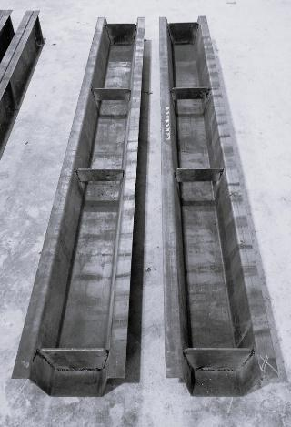

**开口钢槽试件** · 冷弯开口槽实验室试件，Fig. 5(b)。尚未浇筑混凝土，底板、双腹板、窄上翼缘与横向加劲板可见。[图片来源](https://doi.org/10.28991/CEJ-2026-012-03-021) · Ali Allami; Haleem K. Hussain; Fareed H. Majeed · [CC BY 4.0](https://creativecommons.org/licenses/by/4.0/) · 从原文图 5(b) 提取，未修改图像

### 钢箱梁：钢板围成闭口箱

闭口钢箱的抗扭工作方式与开口梁不同。钢箱上设混凝土板并有可靠连接时可组成组合箱梁；也有采用钢桥面板的纯钢箱梁。

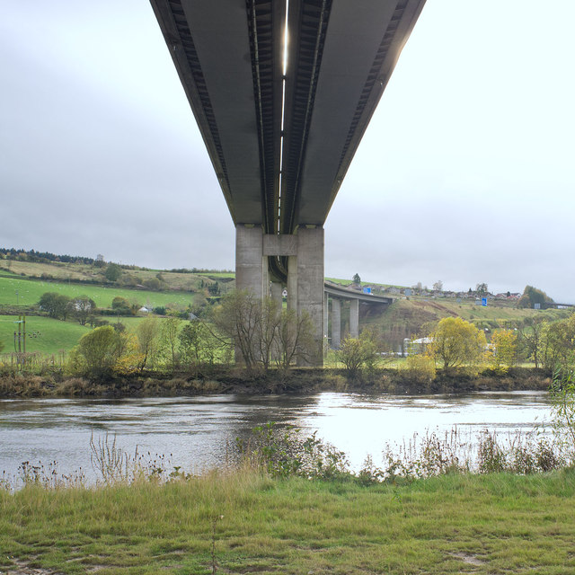

**闭口钢箱组合桥** · Friarton Bridge 桥底实拍。该桥采用焊接钢箱与轻骨料混凝土组合桥面板；照片重点显示钢箱外形，栓钉与顶板内部需看构造示意。[图片来源](https://www.geograph.org.uk/photo/2672422) · Rob Burke · [CC BY-SA 2.0](https://creativecommons.org/licenses/by-sa/2.0/) · 原图缩小展示 · 结构来源

“板梁”侧重构造与制造，“槽梁、箱梁”侧重截面形式，名称不是互斥的材料分类。构造核对：[SCI / BCSA · Box girder bridges](https://steelconstruction.info/sectors/bridges/box-girder-bridges/)。

### 轻量化有收益，整体稳定仍要单独看

对同一支座布置和同一偏载，自重较小可能减小抵抗倾覆的稳定力矩。但轻并不等于必然容易翻倒；支座横向间距、荷载偏心、横向联系和抗倾覆构造都会改变结果。

**梁窄与支座支承范围窄不是一回事。** 荷载合力移向支承范围外时，某侧支座可能先脱空。组合截面抗弯良好，也不代表完整桥梁不会倾覆。阳明滩关联引桥适合讨论这一层问题。

设计荷载、允许通行条件和实际荷载必须分别核对，不能把超载当作正常使用。这里仅解释机制，不复现某次事故的荷载或临界值。[交通运输部关于钢桥整体稳定与抗倾覆的说明](https://xxgk.mot.gov.cn/jigou/glj/202006/t20200623_3312471.html)。

### 施工顺序也不只有一种

本页演示“先架钢梁，再浇混凝土”。也可先预制混凝土桥面板，再与钢梁连接并处理接缝；或在制作场将两者制成组合节段后整体吊装。要逐一确认混凝土强度、连接形成时刻、运输吊点和荷载转移。

### 装配快，不等于没有施工阶段应力

[Queensferry Crossing 的制作流程](https://www.transport.gov.scot/news/100-new-jobs-created-for-queensferry-crossing-steel-delivery-phase/)是在钢节段上浇混凝土，再运到桥位吊装。它提供了另一条建造路线；每一种路线都应保留自己的浇筑、吊装、连接与卸载历史。

**调整跨度、板厚与二期荷载**

跨度 L

跨度增大，挠度明显增加。

板厚

板更厚：组合更刚，也让钢梁先承受更大自重。

二期总线荷载

先施加最多4kN/m铺装，其余为车辆等效荷载。

钢梁 H600×250×12×20 mm · 板有效宽1500 mm · Es/Ec = 200/30 GPa

**教学口径与计算依据**

### 两阶段分别计算，再相加

$一期：qⅠ = g钢 + g湿混凝土，刚度 EₛIₛ二期：qⅡ = g铺装 + q车辆，刚度 EₛI换算δ总 = δⅠ + δⅡσ钢 = σ钢,Ⅰ + Δσ钢,Ⅱσ混凝土 = Δσ混凝土,ⅡMmax = qL²/8，δmax = 5qL⁴/(384EI)$

使用简支梁、全跨均布荷载、短期线弹性及完全组合假定。混凝土逐层、等厚、全跨增加；画中的车辆是等效交通荷载的符号，不计算各轮位置或车辆动力响应。

统一采用钢梁自承模板。模板只作施工构造示意，忽略模板自重；拆模板不造成示例荷载变化。钢梁端支座一直保留，没有地面临时支架方案。

### 形状的历史，受力的起点

混凝土在钢梁已有挠曲上硬化，所以“混凝土已有弯曲形状”不等于“它已经承担一期纵向应力”。硬化时没有新增荷载，应力与挠度不跳变；二期加载后，两种材料共同产生新的应变。

金线保存一期变形，蓝色增量从一期基准继续叠加。抽离一期或二期是数学分解；“只看混凝土”保留它的实际累计形状，但仅显示其二期应力。

默认一期位移放大250倍，二期增量额外放大3倍（即750倍）；此时图形不是统一比例的实际变形。可将二期额外倍率调回1，或点击“真实比例”将两者都还原到1倍。应变、应力与毫米数值不受显示倍率影响。三维应力颜色对钢材和混凝土使用各自独立且跨阶段固定的标尺。全截面图共用真实高度，应变、应力各自采用跨材料与跨阶段一致的横向数值标尺。混凝土详图另用独立 MPa 刻度，沿板厚局部展开；刻度在本次加载期间固定，图形放大不改变应力与合力数值。颜色深浅不能跨材料直接比较，应读取MPa数值。

未计算连接滑移非线性、开裂、徐变收缩、局部与整体稳定、疲劳或极限承载力。板厚较大出现板底拉应力时仍按未开裂截面显示。

混凝土的纵向合力由应力沿板面积积分得到：N꜀ = ∫σ꜀ dA。默认板顶压应力虽只有约 1.58 MPa，板内合压力仍约为 228 kN；钢截面有等值的纵向合拉力。两者及材料自身弯曲共同抵抗外弯矩。

依据：[FHWA分阶段截面](https://www.fhwa.dot.gov/bridge/lrfd/us_ds3.cfm)、[SCI P318应力叠加](https://www.steelconstruction.info/images/e/e0/SCI_P318.pdf)，以及补充课件与桥梁教材的组合梁算例。